# 1: Introduction

What is customer churn? -- When a customer decides to discontinue their relationship with a business/product.

We have a data set from a telecommunications company. Every one of the 1000 customers can subscribe to any combination of the different services the business offers, so it can be hard to analyze each customer and each offering one at a time. However, I am here to faciliate that.

The business experiences a financial burden when a customer churns. It is burdening because it is far more expensive to "buy" a new customer than retain one. It is important for a company to retain customers due to their long-term customer value and intervene with customers on the brink of discontinuing their relationship with the business. My overall goal is to help this business, using a model derived from data they provided, reduce customer churn and aim for longer retention with their current customers.

```python
# Mounting Google Drive
from google.colab import drive
drive.mount('/content/drive')
```

```python
# Import libraries
import pandas as pd
import seaborn as sns

from sklearn.model_selection import train_test_split
from matplotlib import pyplot as plt
from sklearn import tree
from sklearn.tree import DecisionTreeClassifier
from sklearn.metrics import confusion_matrix
from sklearn.metrics import ConfusionMatrixDisplay
from sklearn.metrics import classification_report
from sklearn.naive_bayes import MultinomialNB
```

```python
# Read data
churn = pd.read_csv('/content/drive/MyDrive/IS 470 data/CutomerChurnData.csv')
churn
```

|  | cust_id | region | tenure | age | marital | address | income | ed | employ | retire | gender | reside | tollfree | equip | callcard | wireless | longmon | tollmon | equipmon | cardmon | wiremon | longten | tollten | equipten | cardten | wireten | multline | voice | pager | … |
| --- | --- | --- | --- | --- | --- | --- | --- | --- | --- | --- | --- | --- | --- | --- | --- | --- | --- | --- | --- | --- | --- | --- | --- | --- | --- | --- | --- | --- | --- | --- |
| 0 | C00124 | R2 | 13 | 44 | Y | 9 | 64 | E4 | 5 | N | N | 2 | N | N | Y | N | 3.70 | 0.00 | 0.0 | 7.50 | 0.0 | 37.45 | 0.00 | 0.00 | 110 | 0.0 | N | N | N | … |
| 1 | C00125 | R3 | 68 | 52 | Y | 24 | 116 | E1 | 29 | N | Y | 2 | Y | N | Y | N | 18.15 | 18.00 | 0.0 | 30.25 | 0.0 | 1300.60 | 1247.20 | 0.00 | 2150 | 0.0 | N | N | N | … |
| 2 | C00126 | R2 | 23 | 30 | Y | 9 | 30 | E1 | 2 | N | N | 4 | N | N | N | N | 6.30 | 0.00 | 0.0 | 0.00 | 0.0 | 157.05 | 0.00 | 0.00 | 0 | 0.0 | N | N | N | … |
| 3 | C00127 | R3 | 45 | 22 | Y | 2 | 19 | E2 | 4 | N | Y | 5 | N | N | Y | N | 10.90 | 0.00 | 0.0 | 8.75 | 0.0 | 504.50 | 0.00 | 0.00 | 415 | 0.0 | Y | N | N | … |
| 4 | C00128 | R3 | 45 | 59 | Y | 7 | 166 | E4 | 31 | N | N | 5 | Y | N | Y | N | 9.75 | 28.50 | 0.0 | 12.00 | 0.0 | 449.05 | 1240.15 | 0.00 | 505 | 0.0 | Y | N | N | … |
| ... | ... | ... | ... | ... | ... | ... | ... | ... | ... | ... | ... | ... | ... | ... | ... | ... | ... | ... | ... | ... | ... | ... | ... | ... | ... | ... | ... | ... | ... | … |
| 995 | C01119 | R1 | 50 | 43 | N | 6 | 27 | E3 | 4 | N | N | 1 | Y | N | Y | N | 15.00 | 45.25 | 0.0 | 52.75 | 0.0 | 817.85 | 2320.25 | 0.00 | 2645 | 0.0 | N | N | N | … |
| 996 | C01120 | R1 | 34 | 52 | Y | 2 | 106 | E2 | 19 | N | N | 2 | Y | N | Y | N | 4.95 | 19.00 | 0.0 | 13.50 | 0.0 | 153.50 | 649.35 | 0.00 | 430 | 0.0 | N | N | N | … |
| 997 | C01121 | R1 | 15 | 46 | Y | 17 | 63 | E5 | 1 | N | N | 2 | Y | Y | N | Y | 3.70 | 16.50 | 42.5 | 0.00 | 33.1 | 40.55 | 207.35 | 547.95 | 0 | 475.3 | Y | Y | Y | … |
| 998 | C01122 | R1 | 7 | 34 | N | 2 | 22 | E5 | 5 | N | Y | 1 | N | Y | N | N | 4.65 | 0.00 | 25.6 | 0.00 | 0.0 | 29.35 | 0.00 | 179.10 | 0 | 0.0 | N | N | N | … |
| 999 | C01123 | R3 | 70 | 49 | N | 18 | 87 | E2 | 22 | N | Y | 1 | Y | N | Y | N | 25.60 | 33.50 | 0.0 | 25.25 | 0.0 | 1841.85 | 2368.20 | 0.00 | 1705 | 0.0 | N | Y | N | … |

1000 rows × 39 columns

```python
# Make all column headers visible
churn.keys()
```

```
Index(['cust_id', 'region', 'tenure', 'age', 'marital', 'address', 'income',
       'ed', 'employ', 'retire', 'gender', 'reside', 'tollfree', 'equip',
       'callcard', 'wireless', 'longmon', 'tollmon', 'equipmon', 'cardmon',
       'wiremon', 'longten', 'tollten', 'equipten', 'cardten', 'wireten',
       'multline', 'voice', 'pager', 'internet', 'callid', 'callwait',
       'forward', 'confer', 'ebill', 'loglong', 'lninc', 'custcat', 'churn'],
      dtype='object')
```

```python
# I want more visibility
pd.set_option('display.max_columns', 39)
```

### 1: Introduction Summary

At quick glance exploring the data I notice a few variables that won't be very useful for our model.

- *Cust_id* & *Region* identifies each customer to keep their information organized in this database. Similarly, region does as well. They act as nominal data which are not very useful here.
- *Address* does not give us much. It numerical data but I see customers who share address but not services so I can't derive any meaningful reason to utilize address.
- *Gender* is not telling me if its male or female so it might be a tricky variable to use.
- *loglong* & *lninc* are two logarithmic equations to long-distance service and income respectively. I do not see how that can be useful so I will not be using it.

# 2: Data Understanding and Preprocessing

Here is what we know so far: There is 1000 rows, each row representing a customer (given by cust_id). The 39 columns are a number of attributes associated with the customer and the business.

**Services** -- We can see the services that customers subscribed to: wireless, multiple lines, internet, pager, toll-free, calling card, equipment, electronic bill, forwarding, conferencing, and voice mail.

**Demographics** -- We can see the income, age, gender, region, residence, employment status, retirement status, marital status, address, and education level.

**Customer's activity** -- We can see a customer's tenure, monthly charges for long-distance, toll-free, equipment, calling card, wireless, and the totaly charges for them as well.

Lastly, we have categorical variable of whether a customer has churned or not.

**Objectives:**

1. Is the data clean?
2. Confirm if previously mentioned variables should be ignored?
3. Are there any telling variables when visualizing?
4. What final variables will I model?
5. Discuss whether the data is balanced or not? Explain what we should do if the data was not balanced.

```python
# Learn about data types
churn.info()
```

```
<class 'pandas.core.frame.DataFrame'>
RangeIndex: 1000 entries, 0 to 999
Data columns (total 39 columns):
 #   Column    Non-Null Count  Dtype
---  ------    --------------  -----
 0   cust_id   1000 non-null   object
 1   region    1000 non-null   object
 2   tenure    1000 non-null   int64
 3   age       1000 non-null   int64
 4   marital   1000 non-null   object
 5   address   1000 non-null   int64
 6   income    1000 non-null   int64
 7   ed        1000 non-null   object
 8   employ    1000 non-null   int64
 9   retire    1000 non-null   object
```

[output cut: 31 more lines]

```python
# Examining the statistics of numeric variables
churn.describe()
```

|  | tenure | age | address | income | employ | reside | longmon | tollmon | equipmon | cardmon | wiremon | longten | tollten | equipten | cardten | wireten | loglong | lninc |
| --- | --- | --- | --- | --- | --- | --- | --- | --- | --- | --- | --- | --- | --- | --- | --- | --- | --- | --- |
| count | 1000.000000 | 1000.000000 | 1000.000000 | 1000.000000 | 1000.00000 | 1000.000000 | 1000.000000 | 1000.00000 | 1000.000000 | 1000.000000 | 1000.00000 | 1000.000000 | 1000.000000 | 1000.000000 | 1000.000000 | 1000.000000 | 1000.000000 | 1000.000000 |
| mean | 35.242000 | 41.552000 | 11.576000 | 71.906000 | 10.79000 | 2.316000 | 11.163600 | 13.34350 | 13.572200 | 13.911500 | 10.88070 | 536.994100 | 535.407900 | 440.293200 | 616.090000 | 423.188500 | 2.149468 | 3.926546 |
| std | 21.295937 | 12.679435 | 10.132467 | 80.297826 | 10.14499 | 1.434644 | 9.540451 | 17.41479 | 18.850834 | 14.404653 | 19.24529 | 729.764065 | 867.466796 | 848.250381 | 874.929462 | 961.485455 | 0.716255 | 0.778627 |
| min | 1.000000 | 18.000000 | 0.000000 | 9.000000 | 0.00000 | 1.000000 | 1.050000 | 0.00000 | 0.000000 | 0.000000 | 0.00000 | 1.050000 | 0.000000 | 0.000000 | 0.000000 | 0.000000 | 0.049000 | 2.197000 |
| 25% | 16.000000 | 32.000000 | 3.750000 | 28.000000 | 3.00000 | 1.000000 | 5.150000 | 0.00000 | 0.000000 | 0.000000 | 0.00000 | 86.037500 | 0.000000 | 0.000000 | 0.000000 | 0.000000 | 1.639000 | 3.332000 |
| 50% | 34.500000 | 40.000000 | 9.000000 | 46.000000 | 8.00000 | 2.000000 | 8.500000 | 0.00000 | 0.000000 | 12.125000 | 0.00000 | 288.225000 | 0.000000 | 0.000000 | 362.500000 | 0.000000 | 2.140000 | 3.829000 |
| 75% | 53.000000 | 51.000000 | 18.000000 | 83.250000 | 17.25000 | 3.000000 | 13.862500 | 24.25000 | 30.787500 | 19.562500 | 23.58750 | 700.387500 | 836.912500 | 466.512500 | 871.250000 | 140.075000 | 2.629000 | 4.422000 |
| max | 72.000000 | 77.000000 | 55.000000 | 732.000000 | 47.00000 | 7.000000 | 99.950000 | 173.00000 | 77.700000 | 109.250000 | 109.70000 | 7257.600000 | 4905.850000 | 4758.050000 | 7515.000000 | 6444.950000 | 4.605000 | 6.596000 |

```python
# Examine if categorical variables are balanced -- for demographics
churn['marital'].value_counts(normalize=True), churn['retire'].value_counts(normalize=True), churn['gender'].value_counts(normalize=True), churn['ed'].value_counts(normalize=True), churn['reside'].value_counts(normalize=True),
```

```
(Y    0.504
 N    0.496
 Name: marital, dtype: float64,
 N    0.96
 Y    0.04
 Name: retire, dtype: float64,
 Y    0.502
 N    0.498
 Name: gender, dtype: float64,
 E2    0.290
 E3    0.220
 E1    0.218
 E4    0.216
 E5    0.056
 Name: ed, dtype: float64,
 1    0.382
 2    0.272
 3    0.132
 4    0.118
 5    0.060
 6    0.030
 7    0.006
 Name: reside, dtype: float64)
```

```python
# Examine if categorical variables are balanced -- for services
churn['multline'].value_counts(normalize=True), churn['tollfree'].value_counts(normalize=True), churn['equip'].value_counts(normalize=True),  churn['callcard'].value_counts(normalize=True), churn['wireless'].value_counts(normalize=True), churn['internet'].value_counts(normalize=True), churn['callid'].value_counts(normalize=True), churn['callwait'].value_counts(normalize=True), churn['forward'].value_counts(normalize=True), churn['confer'].value_counts(normalize=True), churn['ebill'].value_counts(normalize=True)
```

```
(N    0.544
 Y    0.456
 Name: multline, dtype: float64,
 N    0.528
 Y    0.472
 Name: tollfree, dtype: float64,
 N    0.63
 Y    0.37
 Name: equip, dtype: float64,
 Y    0.686
 N    0.314
 Name: callcard, dtype: float64,
 N    0.718
 Y    0.282
 Name: wireless, dtype: float64,
 N    0.66
 Y    0.34
 Name: internet, dtype: float64,
 Y    0.502
 N    0.498
 Name: callid, dtype: float64,
 Y    0.502
 N    0.498
 Name: callwait, dtype: float64,
 Y    0.512
 N    0.488
 Name: forward, dtype: float64,
 Y    0.514
 N    0.486
 Name: confer, dtype: float64,
 N    0.63
 Y    0.37
 Name: ebill, dtype: float64)
```

```python
#Examine if last two categorical variables are balanced
churn['churn'].value_counts(normalize=True), churn['custcat'].value_counts(normalize=True),
```

```
(N    0.742
 Y    0.258
 Name: churn, dtype: float64,
 C3    0.290
 C1    0.254
 C4    0.240
 C2    0.216
 Name: custcat, dtype: float64)
```

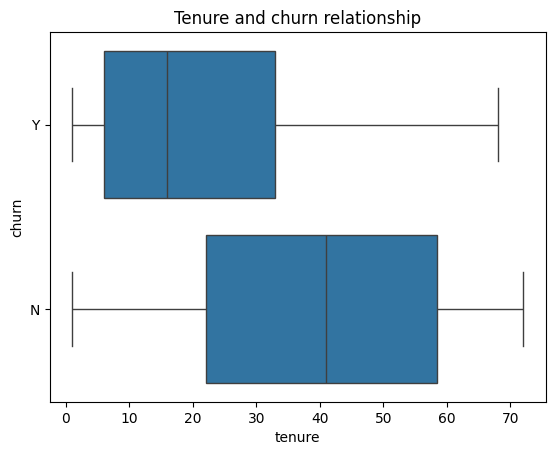

```python
# Examine relationship between tenure and churn with boxplot
tenure_box = sns.boxplot(x='tenure',y='churn', data = churn)
tenure_box.set_title("Tenure and churn relationship")
```

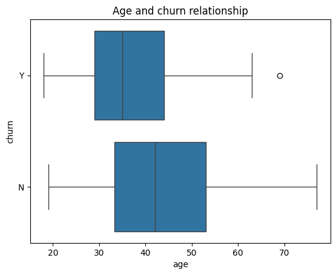

```python
# Examine relationship between age and churn with boxplot
age_box = sns.boxplot(x='age',y='churn', data = churn)
age_box.set_title("Age and churn relationship")
```

```
(0.0, 400.0)
```

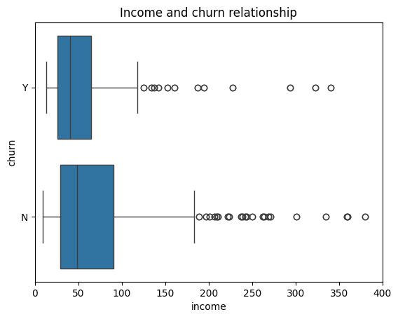

```python
# Examine relationship between income and churn with boxplot
income_box = sns.boxplot(x='income',y='churn', data = churn)
income_box.set_title("Income and churn relationship")
income_box.set_xlim([0, 400])
```

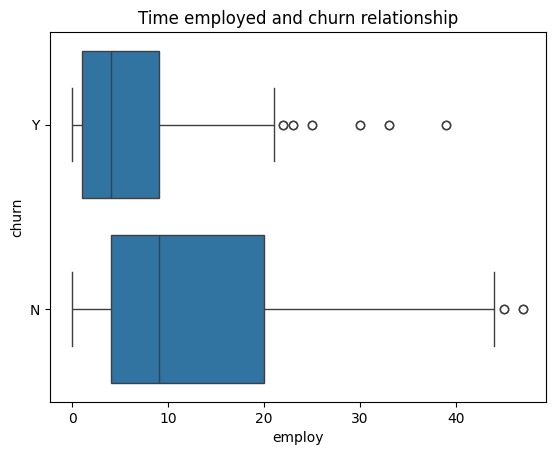

```python
# Examine relationship between time employed and churn with boxplot
employ_box = sns.boxplot(x='employ',y='churn', data = churn)
employ_box.set_title("Time employed and churn relationship")
```

```
(0.0, 2000.0)
```

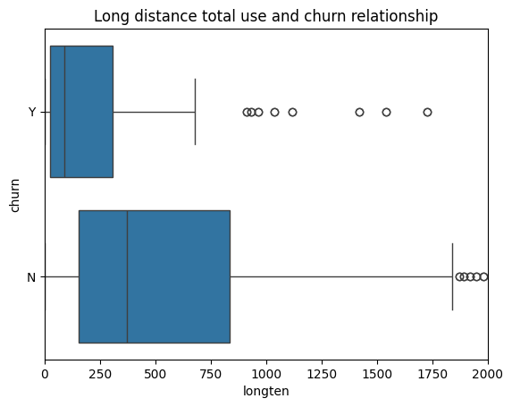

```python
# Examine relationship between long distance calls and churn with boxplot
long_box = sns.boxplot(x='longten',y='churn', data = churn)
long_box.set_title("Long distance total use and churn relationship")
long_box.set_xlim([0, 2000])
```

```
(0.0, 2000.0)
```

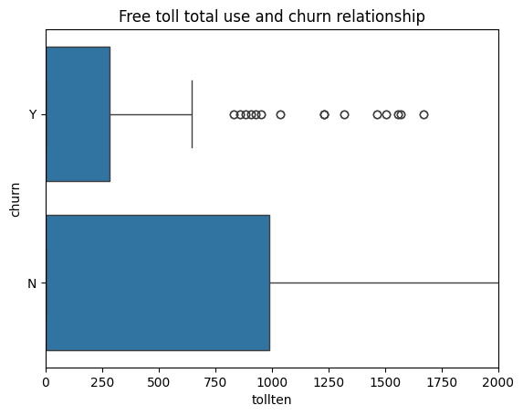

```python
# Examine relationship between free toll service and churn with boxplot
toll_box = sns.boxplot(x='tollten',y='churn', data = churn)
toll_box.set_title("Free toll total use and churn relationship")
toll_box.set_xlim([0, 2000])
```

```
(0.0, 3000.0)
```

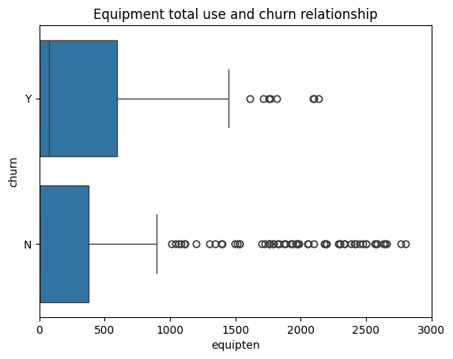

```python
# Examine relationship between equipten and churn with boxplot
equip_box = sns.boxplot(x='equipten',y='churn', data = churn)
equip_box.set_title("Equipment total use and churn relationship")
equip_box.set_xlim([0, 3000])
```

```
(0.0, 2000.0)
```

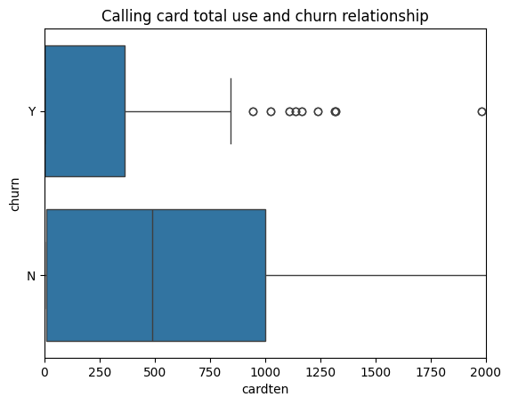

```python
# Examine relationship between callten and churn with boxplot
card_box = sns.boxplot(x='cardten',y='churn', data = churn)
card_box.set_title("Calling card total use and churn relationship")
card_box.set_xlim([0, 2000])
```

```
(0.0, 500.0)
```

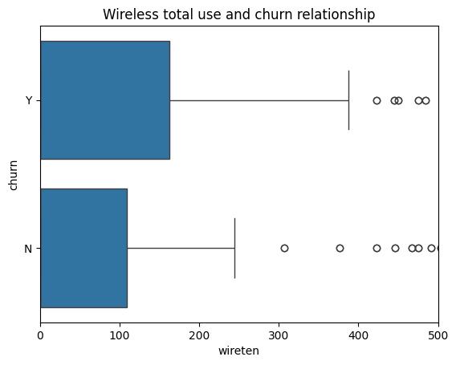

```python
# Examine relationship between wireten and churn with boxplot
wireless_box = sns.boxplot(x='wireten',y='churn', data = churn)
wireless_box.set_title("Wireless total use and churn relationship")
wireless_box.set_xlim([0, 500])
```

### 2 -- Data Understanding and Preprocessing Summary

   I believe the minority services with more variance might be more telling of customer churn. I decided to boxplot all the serviceTenure numerical variables. (serviceTenure instead of serviceMon since its the accumulation of the serviceMon) To my suprise, I found that *equipment* and *wireless* tenures had more churn as tenure increased. That result is different to the other services and opposite to the *tenure* variable, so I included them. It was only logical to add the *equipment* and *wireless* categorical variable.

Q - "Discuss whether the data is balanced or not? Explain what we should do if the data was not balanced. "

# 3: Model Development

Age, tenure, employ, income, equipten, equip, wireten, and wireless on churn is what our decision tree model will be using to determining whether a customer churns or not.

```python
# Use my desired variables
desired_attributes = ['age','tenure','employ','income' ,
                      'equipten','equip', 'wireten','wireless',
                      'churn']
desired_churn_a = churn[desired_attributes]
```

```python
# First, create the "database" that will be used by model. Then replace 'churn' will binary.
teleChurn = desired_churn_a.copy()
teleChurn.loc [:, 'churn'] = teleChurn['churn'].replace({0: 'N', 1:'Y'})
```

```python
# Convert to categorical datatypes
teleChurn['equip'] = teleChurn['equip'].astype('category')
teleChurn['wireless'] = teleChurn['wireless'].astype('category')
```

```python
# Create dummy coded variables
teleChurn = pd.get_dummies(teleChurn, columns=['equip','wireless'], drop_first = True)
teleChurn
```

|  | age | tenure | employ | income | equipten | wireten | churn | equip_Y | wireless_Y |
| --- | --- | --- | --- | --- | --- | --- | --- | --- | --- |
| 0 | 44 | 13 | 5 | 64 | 0.00 | 0.0 | Y | 0 | 0 |
| 1 | 52 | 68 | 29 | 116 | 0.00 | 0.0 | N | 0 | 0 |
| 2 | 30 | 23 | 2 | 30 | 0.00 | 0.0 | N | 0 | 0 |
| 3 | 22 | 45 | 4 | 19 | 0.00 | 0.0 | Y | 0 | 0 |
| 4 | 59 | 45 | 31 | 166 | 0.00 | 0.0 | N | 0 | 0 |
| ... | ... | ... | ... | ... | ... | ... | ... | ... | ... |
| 995 | 43 | 50 | 4 | 27 | 0.00 | 0.0 | N | 0 | 0 |
| 996 | 52 | 34 | 19 | 106 | 0.00 | 0.0 | N | 0 | 0 |
| 997 | 46 | 15 | 1 | 63 | 547.95 | 475.3 | Y | 1 | 1 |
| 998 | 34 | 7 | 5 | 22 | 179.10 | 0.0 | N | 1 | 0 |
| 999 | 49 | 70 | 22 | 87 | 0.00 | 0.0 | N | 0 | 0 |

1000 rows × 9 columns

```python
# Assign churn to variable and examine the porportion of target variable for data set
target = teleChurn['churn']
print(target.value_counts(normalize=True))
```

```
N    0.742
Y    0.258
Name: churn, dtype: float64
```

```python
#Partition the data
predictors = teleChurn.drop(['churn'], axis = 1)
predictors_train, predictors_test, target_train, target_test = train_test_split(predictors, target, test_size=0.3, random_state=0)
print(predictors_train.shape, predictors_test.shape, target_train.shape, target_test.shape)
```

```
(700, 8) (300, 8) (700,) (300,)
```

```python
# Taking steps to balance the train data
# Combine predictors_train and target_train into a single DataFrame
combined_train_df = pd.concat([predictors_train, target_train], axis=1)

# Separate majority and minority classes
majority_df = combined_train_df[combined_train_df['churn'] == 'N']
minority_df = combined_train_df[combined_train_df['churn'] == 'Y']

# Undersample the majority class randomly
undersampled_majority = majority_df.sample(n=len(minority_df), random_state=5)

# Combine the undersampled majority class and the minority class
undersampled_data = pd.concat([undersampled_majority, minority_df])

# Shuffle the combined DataFrame to ensure randomness
balanced_data = undersampled_data.sample(frac=1, random_state=5)

# Split the balanced_data into predictors_train and target_train
predictors_train = balanced_data.drop(columns=['churn'])
target_train = balanced_data['churn']
```

```python
print(target_train.value_counts(normalize=True), target_train.shape)
```

```
N    0.5
Y    0.5
Name: churn, dtype: float64 (342,)
```

```python
print(target_test.value_counts(normalize=True))
```

```
N    0.71
Y    0.29
Name: churn, dtype: float64
```

```python
model_DT = DecisionTreeClassifier(criterion = "entropy", random_state = 1, max_depth = 3)
model_DT.fit(predictors_train, target_train)
```

```
DecisionTreeClassifier(criterion='entropy', max_depth=3, random_state=1)
```

```
[Text(0.5769230769230769, 0.875, 'tenure <= 47.5\nentropy = 1.0\nsamples = 342\nvalue = [171, 171]\nclass = No'),
```

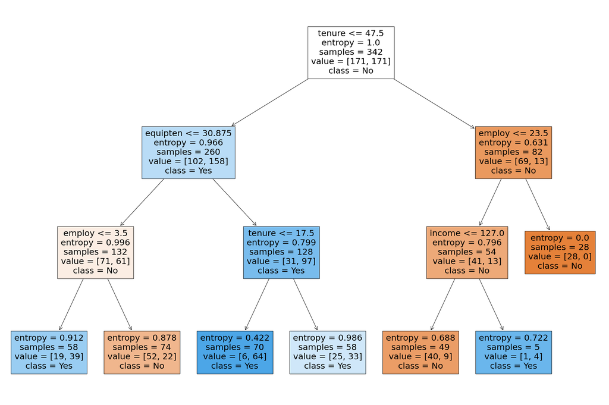

```python
# Plot the tree (0.5 pts)
fig = plt.figure(figsize=(30,20))
tree.plot_tree(model_DT,
               feature_names=list(predictors_train.columns),
               class_names=['No','Yes'],
               filled=True)
```

```python
prediction_on_test_DT = model_DT.predict(predictors_test)
```

```
<sklearn.metrics._plot.confusion_matrix.ConfusionMatrixDisplay at 0x78c9fac7eb00>
```

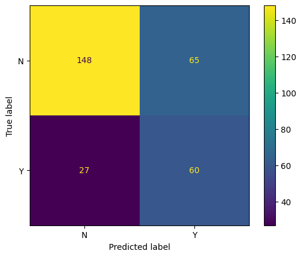

```python
# Examine the evaluation results on testing data: confusion_matrix
cm_DT = confusion_matrix(target_test, prediction_on_test_DT)
ConfusionMatrixDisplay(confusion_matrix=cm_DT, display_labels=model_DT.classes_).plot()
```

```python
# Examine the evaluation results on testing data: accuracy, precision, recall, and f1-score
print(classification_report(target_test, prediction_on_test_DT))
```

```
              precision    recall  f1-score   support

           N       0.85      0.69      0.76       213
           Y       0.48      0.69      0.57        87

    accuracy                           0.69       300
   macro avg       0.66      0.69      0.66       300
weighted avg       0.74      0.69      0.71       300
```

### 3: Model Development Summary

I used the data of 8 variables to help predict customer churn. With the context of customer churn, I am looking for my model to have a high recall in finding Y-churns because the cost of missing a customer who churns is often higher than mistakenly predicting churn for a customer who stays with the company. Successfully identifying a customer that is going to churn and intervening is top priority.

# 4: Results and Model Evaluation

a) **Confusion Matrix & Classification Report:** Our model overall is just shy of ideal accuracy range coming in it 69% overall accruacy. However, because the data is skewed towards N-churn, N-churn has a higher f1-score at 76% compared to Y-churn's 57%. This indicates that the model does a great job in correctly identifying customers who do not churn.

A significant advantage of the model is that Y-churns has a 69% recall. The model's ability to, in reality, correctly identify a substantial proportion of actual Y-churn cases (even if accepts a decent number of N-churns) is extremely valuable in the context of this data. I do need to point out that the model has a low 48% precision rate meaning the model correctly predicts Y-churns less than half the time.

# 5: Conclusion

My analysis aimed to identify potential customers in the data from a telecommunications company using a decision tree classifier. I focused on a subset of variables including demographics, service subscriptions, and tenure to develop a model that can accurately predict a customer churn.

The variables I used were decided by a series of boxplots. I had the numerical variables on the x-axis and churn on the y-axis. The variables that had a considerable difference between the central tendency of the Y-churns and the N-churns were the ones I chose. In addition to the box plots, I eliminated variables such as gender, address, and customer ID that were problematic due to their ambiguity. Regarding the service variables, I carefully thought about my approach to the decision tree by choosing whether I wanted balanced/majority-used services or if I wanted minority-used services. The decision to focus on less common service subscriptions was based on the rationale that core services are unlikely to be the primary drivers of customer dissatisfaction. I made my decisions in the position of the business owner who wants to see if key attributes like tenure, age, and overlooked services are causing customer churn.

This approach yielded a model that reached a recall of 69% for predicting Y-churn, a very strong, number in identifying customers at risk of leaving. This high recall rate is valuable for businesses aiming to intervene and retain customers, even if the precision of identifying churners that are not churning is a little below ideal. It is a trade-off that businesses must recognize because it is more cost-effective to mistakenly target a few N-churners than miss out on retaining Y-churners. As I expressed earlier, it is far more expensive to "buy" a new customer than retain a customer.

The imbalance in predicting churn pointed to areas of improvement. A future approach could consist of utilizing the variables I initially excluded or maybe using different modeling techniques that I'll learn in the future. I was fortunate I had clean data because that facilitated my analyses, but I recognize real-data is not that clean so my approach may change as a result. I thought my approach was carefully thoughtout, from the variables I used and did not use with the reasonings behind those decisions.

```python
!jupyter nbconvert --to html "/content/drive/MyDrive/Colab Notebooks/IS 470 Assignment1-1.ipynb"
```

```
[NbConvertApp] Converting notebook /content/drive/MyDrive/Colab Notebooks/IS 470 Assignment1-1.ipynb to html
[NbConvertApp] Writing 1333786 bytes to /content/drive/MyDrive/Colab Notebooks/IS 470 Assignment1-1.html
```